# **1. Import Library**

```python
# Import Libraries
import pandas as pd
import numpy as np
import matplotlib.pyplot as plt
import seaborn as sns

# Model and Evaluation
from sklearn.model_selection import train_test_split, GridSearchCV
from sklearn.linear_model import LogisticRegression
from sklearn.ensemble import RandomForestClassifier
from sklearn.metrics import accuracy_score, f1_score, classification_report, confusion_matrix

# Preprocessing
from sklearn.preprocessing import StandardScaler

# Dimensionality Reduction
from sklearn.decomposition import PCA
```

# **2. Memuat Dataset dari Hasil Clustering**

```python
df = pd.read_csv('Dataset_inisiasi.csv')
df
```

|  | TransactionAmount | CustomerAge | TransactionDuration | LoginAttempts | AccountBalance | Cluster | TransactionType | Channel |
| --- | --- | --- | --- | --- | --- | --- | --- | --- |
| 0 | 14.09 | 70.0 | 81.0 | 1.0 | 5112.21 | 3 | Debit | ATM |
| 1 | 376.24 | 68.0 | 141.0 | 1.0 | 13758.91 | 3 | Debit | ATM |
| 2 | 126.29 | 19.0 | 56.0 | 1.0 | 1122.35 | 1 | Debit | Online |
| 3 | 184.50 | 26.0 | 25.0 | 1.0 | 8569.06 | 1 | Debit | Online |
| 4 | 13.45 | 26.0 | 198.0 | 1.0 | 7429.40 | 4 | Credit | Online |
| ... | ... | ... | ... | ... | ... | ... | ... | ... |
| 2507 | 856.21 | 33.0 | 109.0 | 1.0 | 12690.79 | 2 | Credit | Branch |
| 2508 | 251.54 | 48.0 | 177.0 | 1.0 | 254.75 | 0 | Debit | Branch |
| 2509 | 28.63 | 56.0 | 146.0 | 1.0 | 3382.91 | 0 | Debit | Branch |
| 2510 | 185.97 | 23.0 | 19.0 | 1.0 | 1776.91 | 1 | Debit | Online |
| 2511 | 243.08 | 24.0 | 93.0 | 1.0 | 131.25 | 4 | Credit | Online |

2512 rows × 8 columns

# **3. Data Splitting**

Pada tahap ini, dilakukan proses pemisahan data untuk keperluan pelatihan dan pengujian model. Dataset akan dibagi menjadi dua bagian, yaitu data latih (80%) dan data uji (20%) menggunakan fungsi `train_test_split`. Proses ini juga menggunakan parameter `stratify=y` untuk memastikan bahwa distribusi kelas pada target (`Cluster`) tetap proporsional di kedua bagian data.

Setelah data dibagi, dilakukan encoding terhadap fitur kategorikal menggunakan one-hot encoding (`pd.get_dummies`). Langkah ini diperlukan agar algoritma machine learning dapat mengolah data kategorikal dalam bentuk numerik.

Agar struktur fitur antara data latih dan data uji konsisten, encoding hasil data uji disesuaikan (`reindex`) agar mencocokkan kolom dari data latih.

Terakhir, seluruh fitur numerik distandardisasi menggunakan `StandardScaler` agar memiliki skala yang seragam (rata-rata = 0 dan standar deviasi = 1). Standardisasi hanya dilakukan berdasarkan data latih, dan kemudian diterapkan ke data uji, sesuai dengan praktik preprocessing yang benar dalam machine learning.

```python
# Melakukan pemisahan fitur (X) dan target (y)
X = df.drop(['Cluster'], axis=1)  # Menghapus kolom 'Cluster' dari fitur
y = df['Cluster']  # Menyimpan kolom 'Cluster' sebagai label/target

# Split data menjadi data latih (80%) dan data uji (20%)
X_train, X_test, y_train, y_test = train_test_split(X, y, test_size=0.2, random_state=42, stratify=y)

# Melakukan encoding pada fitur kategori (one-hot encoding)
# Ini penting agar data kategorikal bisa digunakan oleh algoritma machine learning
X_train_encode = pd.get_dummies(X_train)
X_test_encode = pd.get_dummies(X_test)

# Menyamakan kolom hasil encoding antara train dan test
# (diperlukan jika test set tidak memiliki semua kategori yang ada di train)
X_test_encode = X_test_encode.reindex(columns=X_train_encode.columns, fill_value=0)

# Inisialisasi objek StandardScaler untuk standarisasi (mean = 0, std = 1)
scaler = StandardScaler()

# Melatih scaler hanya dengan data latih, lalu transformasikan ke data latih
X_train_scaled = scaler.fit_transform(X_train_encode)

# Menggunakan scaler yang sudah dilatih untuk transformasi data uji
X_test_scaled = scaler.transform(X_test_encode)
```

Akan dibuat visualisasi yang bertujuan untuk melihat bagaimana distribusi data latih dan data uji setelah dilakukan proses standardisasi. Untuk mempermudah pemahaman secara visual, data yang memiliki dimensi tinggi akan direduksi menjadi dua dimensi menggunakan teknik **Principal Component Analysis (PCA)**.

Dengan memetakan data ke dalam ruang dua dimensi, kita dapat melihat apakah data uji tersebar dengan pola yang mirip seperti data latih atau tidak. Hal ini juga membantu memverifikasi apakah pembagian train-test sudah dilakukan dengan baik, tanpa adanya bias atau pergeseran distribusi.

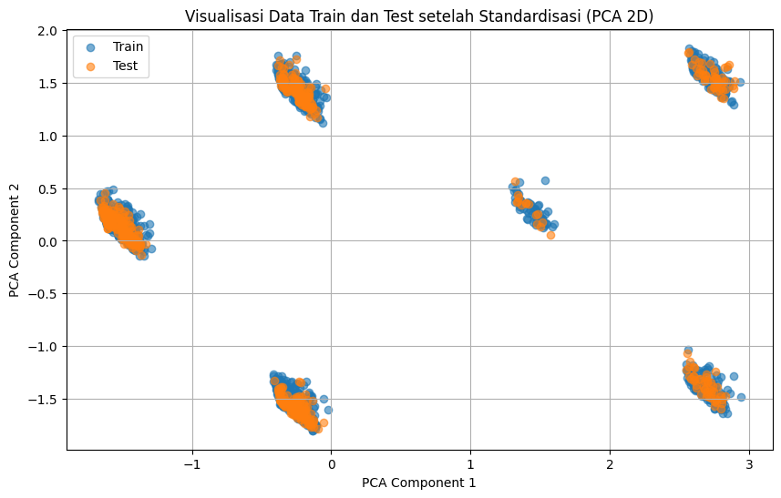

```python
# Gabungkan data train dan test untuk visualisasi
X_combined = np.vstack((X_train_scaled, X_test_scaled))
y_combined = np.hstack((y_train, y_test))
split_label = ['Train'] * len(X_train_scaled) + ['Test'] * len(X_test_scaled)

# Lakukan reduksi dimensi menjadi 2D dengan PCA
pca = PCA(n_components=2)
X_pca = pca.fit_transform(X_combined)

# Buat scatter plot
plt.figure(figsize=(10, 6))
for label in ['Train', 'Test']:
    idx = [i for i, x in enumerate(split_label) if x == label]
    plt.scatter(X_pca[idx, 0], X_pca[idx, 1], label=label, alpha=0.6)

plt.title("Visualisasi Data Train dan Test setelah Standardisasi (PCA 2D)")
plt.xlabel("PCA Component 1")
plt.ylabel("PCA Component 2")
plt.legend()
plt.grid(True)
plt.show()
```

Hasil visualisasi menunjukkan bahwa distribusi data uji (ditandai dengan warna oranye) dan data latih (biru) sangat tumpang tindih dan mengikuti pola yang sama pada setiap cluster. Ini menandakan bahwa pembagian data menggunakan `stratify=y` bekerja dengan baik dan tidak menyebabkan perbedaan distribusi yang signifikan antara data train dan test.

Cluster yang tampak jelas juga menunjukkan bahwa data dalam dataset ini memiliki separabilitas yang tinggi, yang bisa menjelaskan mengapa model klasifikasi mampu mencapai performa yang sangat baik. Hal ini mendukung bahwa proses preprocessing dan splitting yang dilakukan sudah optimal.

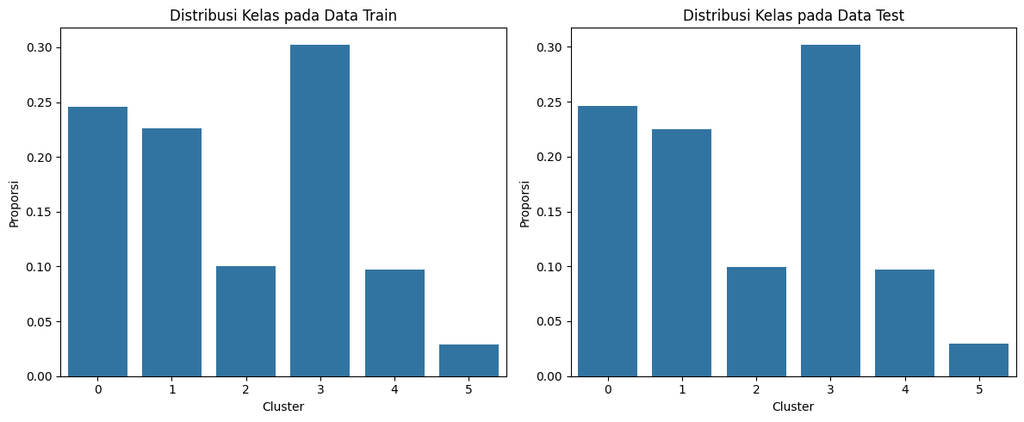

```python
# Hitung distribusi label target pada data train dan test
train_dist = y_train.value_counts(normalize=True).sort_index()
test_dist = y_test.value_counts(normalize=True).sort_index()

# Buat visualisasi side-by-side
fig, axes = plt.subplots(1, 2, figsize=(12, 5))

sns.barplot(x=train_dist.index, y=train_dist.values, ax=axes[0])
axes[0].set_title("Distribusi Kelas pada Data Train")
axes[0].set_xlabel("Cluster")
axes[0].set_ylabel("Proporsi")

sns.barplot(x=test_dist.index, y=test_dist.values, ax=axes[1])
axes[1].set_title("Distribusi Kelas pada Data Test")
axes[1].set_xlabel("Cluster")
axes[1].set_ylabel("Proporsi")

plt.tight_layout()
plt.show()
```

Hasil visualisasi menunjukkan bahwa distribusi kelas pada data train dan test sangat mirip, meskipun terdapat sedikit variasi kecil yang wajar. Setiap kelas (`Cluster 0` hingga `Cluster 5`) memiliki proporsi yang relatif konsisten antara data latih dan data uji.

Hal ini mengindikasikan bahwa pembagian data dengan `stratify=y` berjalan efektif, sehingga tidak terjadi ketimpangan kelas di antara subset. Distribusi yang seimbang ini sangat penting agar model tidak bias terhadap kelas tertentu, serta dapat belajar dan diuji secara adil pada semua label.

Terlihat bahwa pembagiannya tidak seimbang atau imbalanced. Oleh karena itu, dalam pemodelan nanti akan digunakan class_weight='balanced' untuk mengatasi masalah ini.

# **4. Membangun Model Klasifikasi**

## **a. Membangun Model Klasifikasi**

Pada kasus ini, saya membandingkan dua algoritma klasifikasi untuk memodelkan target variabel `Cluster`, yaitu **Random Forest** dan **Logistic Regression**. Kedua algoritma ini dipilih karena memiliki pendekatan yang berbeda dalam memecahkan masalah klasifikasi dan cocok digunakan untuk data tabular seperti pada dataset ini.

1. Logistic Regression Multiclass

**Logistic Regression** adalah algoritma linier yang digunakan untuk klasifikasi, bukan regresi seperti namanya. Untuk kasus multi-kelas seperti ini, digunakan pendekatan **multinomial logistic regression**.

#### Keunggulan:

- Model yang sederhana dan mudah diinterpretasikan.
- Cepat dalam pelatihan dan prediksi.
- Cocok sebagai baseline model untuk klasifikasi.

#### Alasan Pemilihan:

Logistic Regression merupakan model yang efisien dan memberikan pemahaman dasar yang baik terhadap data. Model ini berguna sebagai pembanding untuk melihat seberapa baik model non-linier (seperti Random Forest) bekerja pada dataset yang sama.

```python
# Inisialisasi model Logistic Regression dengan pendekatan multinomial
# karena target 'Cluster' terdiri dari lebih dari dua kelas (multi-kelas).
# random_state=42 digunakan untuk memastikan hasil yang reproducible.
lr_model = LogisticRegression(multi_class='multinomial', class_weight='balanced', random_state=42)

# Melatih (fitting) model Logistic Regression dengan data training yang telah distandardisasi
lr_model.fit(X_train_scaled, y_train)
```

```
LogisticRegression(class_weight='balanced', multi_class='multinomial',
                   random_state=42)
```

Cell di atas menjalankan Logistic Regression Multinomial, yaitu varian dari logistic regression yang digunakan saat kelas target lebih dari dua (multi-class classification). Model akan mempelajari hubungan linier antara fitur-fitur input (setelah distandardisasi) dan kelas target Cluster. Model ini mengasumsikan bahwa log odds dari probabilitas tiap kelas merupakan fungsi linier dari fitur. Proses .fit() berarti model sedang mempelajari koefisien (weights) untuk masing-masing fitur agar bisa memprediksi probabilitas kelas seakurat mungkin.

2. Random Forest

**Random Forest** adalah algoritma berbasis ensemble learning yang membangun banyak pohon keputusan (decision trees) dan menggabungkan hasilnya (dengan voting mayoritas untuk klasifikasi) untuk menghasilkan prediksi yang lebih akurat dan stabil.

#### Keunggulan:

- Tahan terhadap overfitting.
- Dapat menangani fitur numerik maupun kategorikal (setelah encoding).
- Menyediakan informasi penting seperti *feature importance*.

#### Alasan Pemilihan:

Random Forest sangat cocok untuk dataset dengan struktur dan skala fitur yang bervariasi, serta mampu menangani hubungan non-linear antar fitur.

```python
# Inisialisasi model Random Forest Classifier dengan random_state untuk hasil yang konsisten
rf_model = RandomForestClassifier(random_state=42, class_weight='balanced')

# Melatih model Random Forest dengan data training yang telah distandardisasi
# Sebenarnya, Random Forest tidak wajib distandardisasi, tapi tetap bisa bekerja tanpa masalah.
rf_model.fit(X_train_scaled, y_train)
```

```
RandomForestClassifier(class_weight='balanced', random_state=42)
```

Random Forest adalah algoritma ensemble yang membangun banyak decision tree dari subset acak data, lalu menggabungkan hasil prediksinya. Setiap tree dilatih dengan data berbeda (dari teknik bootstrap sampling), dan menggunakan subset acak dari fitur saat membagi node → membuat model lebih tahan terhadap overfitting. Proses .fit() berarti model sedang membangun banyak pohon keputusan berdasarkan data training untuk mengenali pola dan memetakan input ke label Cluster.

## **b. Evaluasi Model Klasifikasi**

Pada eksperimen ini, dua algoritma klasifikasi telah digunakan untuk memprediksi label `Cluster`, yaitu:

1. **Logistic Regression** dengan `multi_class='multinomial'` dan `class_weight='balanced'`
2. **Random Forest Classifier** dengan `class_weight='balanced'

```python
# --- Prediksi menggunakan data uji ---
y_pred_rf = rf_model.predict(X_test_scaled)
y_pred_lr = lr_model.predict(X_test_scaled)
```

```python
# --- Evaluasi Logistic Regression ---
print("\n=== Logistic Regression ===")
print("Accuracy:", accuracy_score(y_test, y_pred_lr))
print("F1-Score (macro):", f1_score(y_test, y_pred_lr, average='macro'))
print("Classification Report:\n", classification_report(y_test, y_pred_lr))
print("Confusion Matrix:\n", confusion_matrix(y_test, y_pred_lr))
```

```
=== Logistic Regression ===
Accuracy: 1.0
F1-Score (macro): 1.0
Classification Report:
               precision    recall  f1-score   support

           0       1.00      1.00      1.00       124
           1       1.00      1.00      1.00       113
           2       1.00      1.00      1.00        50
           3       1.00      1.00      1.00       152
           4       1.00      1.00      1.00        49
           5       1.00      1.00      1.00        15

    accuracy                           1.00       503
   macro avg       1.00      1.00      1.00       503
weighted avg       1.00      1.00      1.00       503

Confusion Matrix:
 [[124   0   0   0   0   0]
 [  0 113   0   0   0   0]
 [  0   0  50   0   0   0]
 [  0   0   0 152   0   0]
 [  0   0   0   0  49   0]
 [  0   0   0   0   0  15]]
```

**Hasil Evaluasi: Logistic Regression**

- **Accuracy**: 1.00
- **F1-Score (macro)**: 1.00
- **Classification Report**:
  - Semua kelas (0–5) memiliki precision, recall, dan F1-score sebesar **1.00**
- **Confusion Matrix** menunjukkan bahwa semua prediksi benar sesuai kelasnya tanpa ada kesalahan klasifikasi.

```python
# --- Evaluasi Random Forest ---
print("=== Random Forest ===")
print("Accuracy:", accuracy_score(y_test, y_pred_rf))
print("F1-Score (macro):", f1_score(y_test, y_pred_rf, average='macro'))
print("Classification Report:\n", classification_report(y_test, y_pred_rf))
print("Confusion Matrix:\n", confusion_matrix(y_test, y_pred_rf))
```

```
=== Random Forest ===
Accuracy: 1.0
F1-Score (macro): 1.0
Classification Report:
               precision    recall  f1-score   support

           0       1.00      1.00      1.00       124
           1       1.00      1.00      1.00       113
           2       1.00      1.00      1.00        50
           3       1.00      1.00      1.00       152
           4       1.00      1.00      1.00        49
           5       1.00      1.00      1.00        15

    accuracy                           1.00       503
   macro avg       1.00      1.00      1.00       503
weighted avg       1.00      1.00      1.00       503

Confusion Matrix:
 [[124   0   0   0   0   0]
 [  0 113   0   0   0   0]
 [  0   0  50   0   0   0]
 [  0   0   0 152   0   0]
 [  0   0   0   0  49   0]
 [  0   0   0   0   0  15]]
```

**Hasil Evaluasi: Random Forest**

- **Accuracy**: 1.00
- **F1-Score (macro)**: 1.00
- **Classification Report**:
  - Semua metrik juga menunjukkan nilai sempurna (1.00) untuk tiap kelas.
- **Confusion Matrix** identik dengan Logistic Regression, tidak ada kesalahan klasifikasi.

**Perbandingan dan Interpretasi**

| Metrik | Logistic Regression | Random Forest |
| --- | --- | --- |
| Accuracy | 1.00 | 1.00 |
| F1-Score (macro) | 1.00 | 1.00 |
| Kesalahan Prediksi | 0 | 0 |

- Kedua model menghasilkan **akurasi dan F1-score sempurna (100%)**.
- Ini menunjukkan bahwa dataset ini mungkin **sangat terstruktur dan mudah dipisahkan antar kelas** oleh model.
- Bisa juga disebabkan oleh **overfitting**, terutama jika evaluasi dilakukan pada data yang terlalu mirip dengan data latih.

## **c. Tuning Model Klasifikasi (Optional)**

Untuk mengetahui apakah terjadi overfitting pada model, kita dapat melakukan tuning hyperparameter dengan menggunakan **GridSearchCV**. Proses ini akan mencari kombinasi hyperparameter terbaik yang menghasilkan performa model optimal. Digunakan cv=58 karena jumlah paling kecil pada target variabel `Cluster` adalah 58.

```python
# GridSearchCV untuk Random Forest
# Definisikan parameter grid
param_grid_lr = {
    'C': [0.01, 0.1, 1, 10],
    'solver': ['lbfgs', 'saga'],
    'multi_class': ['multinomial'],
    'class_weight': ['balanced']
}

# Inisialisasi model dasar
lr = LogisticRegression(max_iter=1000, random_state=42)

# Grid Search
grid_lr = GridSearchCV(estimator=lr, param_grid=param_grid_lr,
                       cv=58, scoring='f1_macro', n_jobs=-1)

# Jalankan Grid Search
grid_lr.fit(X_train_scaled, y_train)
```

```
GridSearchCV(cv=58,
             estimator=LogisticRegression(max_iter=1000, random_state=42),
             n_jobs=-1,
             param_grid={'C': [0.01, 0.1, 1, 10], 'class_weight': ['balanced'],
                         'multi_class': ['multinomial'],
                         'solver': ['lbfgs', 'saga']},
             scoring='f1_macro')
```

```python
# Definisikan parameter grid untuk dicoba
param_grid_rf = {
    'n_estimators': [100, 200],
    'max_depth': [None, 10, 20],
    'min_samples_split': [2, 5],
    'min_samples_leaf': [1, 2],
    'class_weight': ['balanced']
}

# Inisialisasi model dasar
rf = RandomForestClassifier(random_state=42)

# Grid Search
grid_rf = GridSearchCV(estimator=rf, param_grid=param_grid_rf,
                       cv=58, scoring='f1_macro', n_jobs=-1)

# Jalankan Grid Search
grid_rf.fit(X_train_scaled, y_train)
```

```
GridSearchCV(cv=58, estimator=RandomForestClassifier(random_state=42),
             n_jobs=-1,
             param_grid={'class_weight': ['balanced'],
                         'max_depth': [None, 10, 20],
                         'min_samples_leaf': [1, 2],
                         'min_samples_split': [2, 5],
                         'n_estimators': [100, 200]},
             scoring='f1_macro')
```

## **d. Evaluasi Model Klasifikasi setelah Tuning (Optional)**

```python
# Tampilkan hasil terbaik
print("Best Parameters (Logistic Regression):", grid_lr.best_params_)

# Print Classification Report Matrix
y_pred_lr_grid = grid_lr.best_estimator_.predict(X_test_scaled)
print("\n=== Logistic Regression (Grid Search) ===")
print("Accuracy:", accuracy_score(y_test, y_pred_lr_grid))
print("F1-Score (macro):", f1_score(y_test, y_pred_lr_grid, average='macro'))
print("Classification Report:\n", classification_report(y_test, y_pred_lr_grid))
print("Confusion Matrix:\n", confusion_matrix(y_test, y_pred_lr_grid))
```

```
Best Parameters (Logistic Regression): {'C': 0.01, 'class_weight': 'balanced', 'multi_class': 'multinomial', 'solver': 'lbfgs'}

=== Logistic Regression (Grid Search) ===
Accuracy: 1.0
F1-Score (macro): 1.0
Classification Report:
               precision    recall  f1-score   support

           0       1.00      1.00      1.00       124
           1       1.00      1.00      1.00       113
           2       1.00      1.00      1.00        50
           3       1.00      1.00      1.00       152
           4       1.00      1.00      1.00        49
           5       1.00      1.00      1.00        15

    accuracy                           1.00       503
   macro avg       1.00      1.00      1.00       503
weighted avg       1.00      1.00      1.00       503

Confusion Matrix:
 [[124   0   0   0   0   0]
 [  0 113   0   0   0   0]
 [  0   0  50   0   0   0]
 [  0   0   0 152   0   0]
 [  0   0   0   0  49   0]
 [  0   0   0   0   0  15]]
```

```python
# Tampilkan hasil terbaik
print("Best Parameters (Random Forest):", grid_rf.best_params_)

# Print Classification Report Matrix
y_pred_rf_grid = grid_rf.best_estimator_.predict(X_test_scaled)
print("\n=== Random Forest (Grid Search) ===")
print("Accuracy:", accuracy_score(y_test, y_pred_rf_grid))
print("F1-Score (macro):", f1_score(y_test, y_pred_rf_grid, average='macro'))
print("Classification Report:\n", classification_report(y_test, y_pred_rf_grid))
print("Confusion Matrix:\n", confusion_matrix(y_test, y_pred_rf_grid))
```

```
Best Parameters (Random Forest): {'class_weight': 'balanced', 'max_depth': None, 'min_samples_leaf': 1, 'min_samples_split': 2, 'n_estimators': 100}

=== Random Forest (Grid Search) ===
Accuracy: 1.0
F1-Score (macro): 1.0
Classification Report:
               precision    recall  f1-score   support

           0       1.00      1.00      1.00       124
           1       1.00      1.00      1.00       113
           2       1.00      1.00      1.00        50
           3       1.00      1.00      1.00       152
           4       1.00      1.00      1.00        49
           5       1.00      1.00      1.00        15

    accuracy                           1.00       503
   macro avg       1.00      1.00      1.00       503
weighted avg       1.00      1.00      1.00       503

Confusion Matrix:
 [[124   0   0   0   0   0]
 [  0 113   0   0   0   0]
 [  0   0  50   0   0   0]
 [  0   0   0 152   0   0]
 [  0   0   0   0  49   0]
 [  0   0   0   0   0  15]]
```

## **e. Analisis Hasil Evaluasi Model Klasifikasi**

### 1. **Perbandingan Hasil Evaluasi Sebelum dan Setelah Tuning**

Hasil evaluasi yang dilakukan sebelum dan setelah proses tuning menggunakan **GridSearchCV** menunjukkan bahwa kedua model — **Logistic Regression** dan **Random Forest** — telah mencapai performa yang sangat tinggi. Nilai **Accuracy** dan **F1-Score (macro)** pada data uji adalah **1.00 (100%)** baik sebelum maupun setelah tuning.

Hal ini menunjukkan bahwa **tuning hyperparameter tidak meningkatkan akurasi**, karena model sudah mencapai performa maksimal bahkan sebelum tuning dilakukan. Meski demikian, proses tuning tetap memberikan pemahaman yang lebih mendalam tentang kombinasi **parameter optimal** untuk model.

### 2. **Identifikasi Kelemahan Model**

- **Precision dan Recall**  
  Berdasarkan classification report dan confusion matrix, terlihat bahwa seluruh kelas (0 hingga 5) memiliki **precision, recall, dan F1-score yang sempurna (1.00)**. Semua kelas berhasil diklasifikasikan dengan sangat baik tanpa ada yang terabaikan.
- **Overfitting atau Underfitting**  
  Tidak ada indikasi **underfitting**, karena performa model sangat tinggi. Namun, hasil yang sempurna ini berpotensi mengarah pada **overfitting**, terutama jika data latih dan data uji sangat mirip, atau jika pola dalam data terlalu mudah dipelajari oleh model.

  Walaupun **cross-validation** dengan `cv=58` telah digunakan untuk mengurangi risiko overfitting, evaluasi menggunakan **data eksternal** atau **data baru** yang belum pernah dilihat oleh model tetap diperlukan. Hal ini akan memberikan gambaran yang lebih realistis tentang kemampuan model dalam menghadapi situasi di dunia nyata.

### 3. **Rekomendasi Tindakan Lanjutan**

- **Validasi lebih lanjut dengan data baru** sangat penting untuk memastikan bahwa model benar-benar dapat melakukan generalisasi dengan baik.
- Meskipun kedua model yang digunakan telah memberikan hasil yang optimal, eksplorasi model lain seperti **XGBoost** atau **Gradient Boosting** bisa menjadi pilihan untuk membandingkan kinerja lebih lanjut.
- Dengan **penambahan data** di masa depan, melatih ulang model menggunakan dataset yang lebih besar sangat disarankan untuk menjaga kualitas generalisasi.
- Pengurangan fitur (feature ablation) bisa menjadi langkah yang berguna untuk menguji seberapa sensitif model terhadap fitur tertentu dan memastikan tidak ada fitur yang secara tidak sengaja mempengaruhi hasil.

### **Kesimpulan**

Model yang dikembangkan dalam studi ini menunjukkan performa klasifikasi yang sangat tinggi, baik sebelum maupun setelah tuning. Namun, meskipun hasil yang dicapai terlihat sempurna, evaluasi lebih lanjut dengan data yang belum pernah dilihat dan **stress testing** tetap diperlukan untuk memastikan bahwa hasil ini tidak hanya disebabkan oleh **overfitting** terhadap dataset yang digunakan.